# Excercise 9

Sarah Greve

11/13/2018

*Repeat the differential gene expression analysis*

```r
#repeat the analysis
library(pasilla)
library(edgeR)
library(DEXSeq)
setwd("/Users/greves/Desktop/Sarah")
samples <- read.table("samples.txt", header=TRUE,
                      row.names=5, stringsAsFactors=FALSE)
samples
```

```
##                   rep condition libtype shortname           countfile
## CG8144_RNAi-1.bam  T1         T      SE     T1.SE CG8144_RNAi-1.count
## CG8144_RNAi-3.bam  T3         T      PE     T3.PE CG8144_RNAi-3.count
## CG8144_RNAi-4.bam  T4         T      PE     T4.PE CG8144_RNAi-4.count
## Untreated-1.bam    C1         C      SE     C1.SE   Untreated-1.count
## Untreated-6.bam    C6         C      SE     C6.SE   Untreated-6.count
## Untreated-3.bam    C3         C      PE     C3.PE   Untreated-3.count
## Untreated-4.bam    C4         C      PE     C4.PE   Untreated-4.count
```

```r
# load DGE list in R
counts <- readDGE(samples$countfile)$counts

grp <- gsub("\\-.[0-9]*","",colnames(counts))
grp
```

```
## [1] "CG8144_RNAi" "CG8144_RNAi" "CG8144_RNAi" "Untreated"   "Untreated"
## [6] "Untreated"   "Untreated"
```

```r
group <- factor(c(1,1,1,2,2,2,2))
y <- DGEList(counts=counts,group=group)

#identify low expressed genes (cpm > 1)
keep <- rowSums(cpm(y)>1) >= 2
y <- y[keep, ,keep.lib.sizes = FALSE]

y <- calcNormFactors(y)
design <- model.matrix(~group)

y <- estimateDisp(y,design)
#To perform likelihood ratio tests:
fit <- glmFit(y,design)
lrt <- glmLRT(fit,coef=2)
topTags(lrt)
```

```
## Coefficient:  group2
##                 logFC   logCPM       LR        PValue           FDR
## FBgn0039155  4.623427 5.717642 623.9774 1.020207e-137 8.295306e-134
## FBgn0039827  4.037694 4.249950 313.6579  3.486477e-70  1.417427e-66
## FBgn0025111 -2.920955 6.712858 295.4703  3.196371e-66  8.663231e-63
## FBgn0034736  3.544548 3.992156 228.0506  1.586636e-51  3.225234e-48
## FBgn0003360  3.178152 8.272895 225.7333  5.080100e-51  8.261258e-48
## FBgn0035085  2.537002 5.433659 217.1966  3.697362e-49  5.010541e-46
## FBgn0029167  2.211486 8.030173 199.9579  2.133180e-45  2.477841e-42
## FBgn0000071 -2.705282 4.575573 197.6466  6.814231e-45  6.925814e-42
## FBgn0029896  2.420249 5.097134 179.7483  5.500285e-41  4.969202e-38
## FBgn0034434  3.540659 3.010768 177.9918  1.330135e-40  1.081533e-37
```

*Question 1*

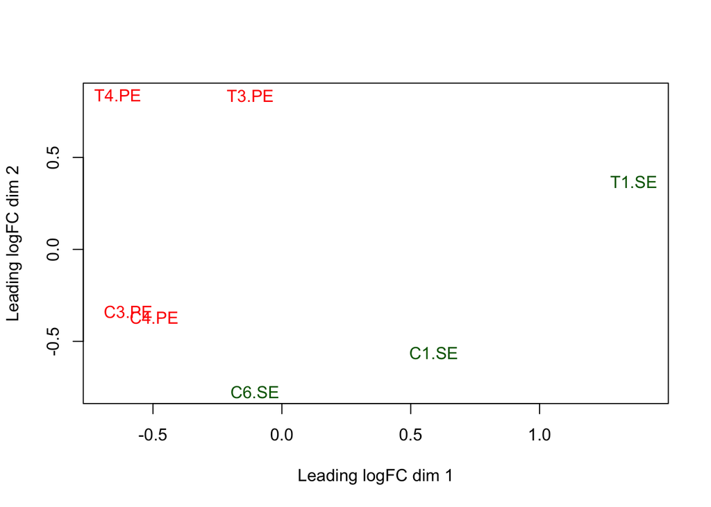

```r
# perform multidimensional scaling and display also the different batches
plotMDS(y, col = c("darkgreen", "red", "red", "darkgreen", "darkgreen", "red", "red"), labels = samples$shortname)
```

The MDS plot above shows two clusters of samples in the first dimension, indicated by libtype. Based on this in downstream analysis it is essential to account for the libtype as a batch effect.

```r
# repeat edge R analysis considering the libtype as batch effect.
setwd("/Users/greves/Desktop/Sarah")
samples <- read.table("samples.txt", header=TRUE,
                      row.names=5, stringsAsFactors=FALSE)
samples
```

```
##                   rep condition libtype shortname           countfile
## CG8144_RNAi-1.bam  T1         T      SE     T1.SE CG8144_RNAi-1.count
## CG8144_RNAi-3.bam  T3         T      PE     T3.PE CG8144_RNAi-3.count
## CG8144_RNAi-4.bam  T4         T      PE     T4.PE CG8144_RNAi-4.count
## Untreated-1.bam    C1         C      SE     C1.SE   Untreated-1.count
## Untreated-6.bam    C6         C      SE     C6.SE   Untreated-6.count
## Untreated-3.bam    C3         C      PE     C3.PE   Untreated-3.count
## Untreated-4.bam    C4         C      PE     C4.PE   Untreated-4.count
```

```r
# load DGE list in R
counts <- readDGE(samples$countfile)$counts

grp <- gsub("\\-.[0-9]*","",colnames(counts))
grp
```

```
## [1] "CG8144_RNAi" "CG8144_RNAi" "CG8144_RNAi" "Untreated"   "Untreated"
## [6] "Untreated"   "Untreated"
```

```r
group <- factor(c(1,1,1,2,2,2,2))
y2 <- DGEList(counts=counts,group=group)

#identify low expressed genes (cpm > 1)
keep <- rowSums(cpm(y2)>1) >= 2
y2 <- y2[keep, ,keep.lib.sizes = FALSE]

# add libtype as covariate to the design matrix
y2 <- calcNormFactors(y2)
design2 <- model.matrix(~group+samples$libtype)

y2 <- estimateDisp(y2,design2)
#To perform likelihood ratio tests and consider the batch effect
fit2 <- glmQLFit(y2,design2)
qlf <- glmQLFTest(fit2,coef=2)
```

```r
topTags(qlf)
```

```
## Coefficient:  group2
##                 logFC    logCPM         F       PValue          FDR
## FBgn0025111 -2.858286  6.712275 1232.4050 3.204967e-11 1.396400e-07
## FBgn0039155  4.620486  5.717943 1214.1035 3.434757e-11 1.396400e-07
## FBgn0035085  2.576015  5.431438  737.7189 3.428905e-10 9.293474e-07
## FBgn0039827  4.059922  4.245341  636.0748 6.784526e-10 1.236089e-06
## FBgn0003360  3.116143  8.273220  603.6496 8.629484e-10 1.236089e-06
## FBgn0000071 -2.644512  4.573790  569.1739 1.130599e-09 1.236089e-06
## FBgn0034736  3.584118  3.987777  562.5660 1.192871e-09 1.236089e-06
## FBgn0026562  2.453642 11.606860  560.2003 1.216174e-09 1.236089e-06
## FBgn0029167  2.212987  8.029988  545.8600 1.369893e-09 1.237622e-06
## FBgn0034434  3.557675  3.006366  355.4725 9.733201e-09 7.236641e-06
```

```r
topTags(lrt)
```

```
## Coefficient:  group2
##                 logFC   logCPM       LR        PValue           FDR
## FBgn0039155  4.623427 5.717642 623.9774 1.020207e-137 8.295306e-134
## FBgn0039827  4.037694 4.249950 313.6579  3.486477e-70  1.417427e-66
## FBgn0025111 -2.920955 6.712858 295.4703  3.196371e-66  8.663231e-63
## FBgn0034736  3.544548 3.992156 228.0506  1.586636e-51  3.225234e-48
## FBgn0003360  3.178152 8.272895 225.7333  5.080100e-51  8.261258e-48
## FBgn0035085  2.537002 5.433659 217.1966  3.697362e-49  5.010541e-46
## FBgn0029167  2.211486 8.030173 199.9579  2.133180e-45  2.477841e-42
## FBgn0000071 -2.705282 4.575573 197.6466  6.814231e-45  6.925814e-42
## FBgn0029896  2.420249 5.097134 179.7483  5.500285e-41  4.969202e-38
## FBgn0034434  3.540659 3.010768 177.9918  1.330135e-40  1.081533e-37
```

*Summary of differential gene expression without accountance for the libtype*

```r
#compare set of differential expressed genes from adjusted and unadjusted model
summary(decideTests(lrt))
```

```
##        group2
## Down      324
## NotSig   7486
## Up        321
```

*Summary of differential gene expression with accountance of the libtype*

```r
summary(decideTests(qlf))
```

```
##        group2
## Down      497
## NotSig   7098
## Up        536
```

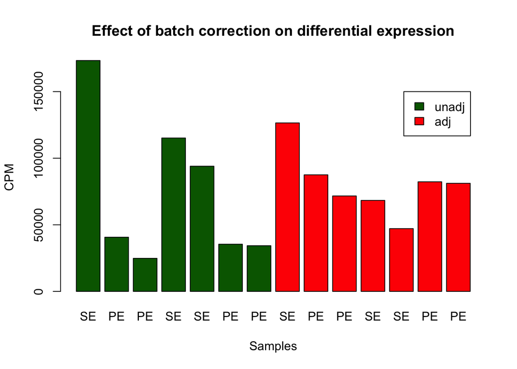

```r
# calculate CPMs with and without consideration of the batch effect
unadj <- cpm(y)
#adjust for libtype
adj <- removeBatchEffect(unadj, batch = samples$libtype)

comb <- cbind(unadj, adj)

#identify gene which is the influenced by batch affect
comb <- cbind(comb, rowMeans(comb[,1:7]-rowMeans(comb [,8:14])))
comb <- data.frame(comb)
gene_batch <- comb [order(comb$V15, decreasing = F),]

# plot particular gene to visualize effect of batch correction
gene <- as.numeric(gene_batch [1,1:14])

barplot(gene, col = c(rep("darkgreen", 7), rep("red", 7)), main = "Effect of batch correction on differential expression", xlab = "Samples", ylab = "CPM", names.arg = c(rep(samples$libtype,2)))

legend(14, 150000,legend=c("unadj", "adj"),
       fill=c("darkgreen", "red"))
```

The figure above depicts a gene which is solely affected by the libtype. In the unadjusted model,paired end sequencing leads to a continous lower count number of the gene then the single end sequencing. In case the data set is adjusted for the libtype, the difference between single and paired end sequenced samples is removed.

```r
library(pasilla)
sdir <- file.path(system.file(package="pasilla"), "extdata")
anno <- file.path(sdir, "Dmel.BDGP5.25.62.DEXSeq.chr.gff")

samplesX = data.frame(cond = rep( c("trt","untrt"), c(3,4) ),
                      type = c("SE","PE","PE","SE","SE","PE","PE"),
                      countfile = dir(sdir,pattern="fb.txt"),
                      stringsAsFactors = TRUE)
samplesX
```

```
##    cond type        countfile
## 1   trt   SE   treated1fb.txt
## 2   trt   PE   treated2fb.txt
## 3   trt   PE   treated3fb.txt
## 4 untrt   SE untreated1fb.txt
## 5 untrt   SE untreated2fb.txt
## 6 untrt   PE untreated3fb.txt
## 7 untrt   PE untreated4fb.txt
```

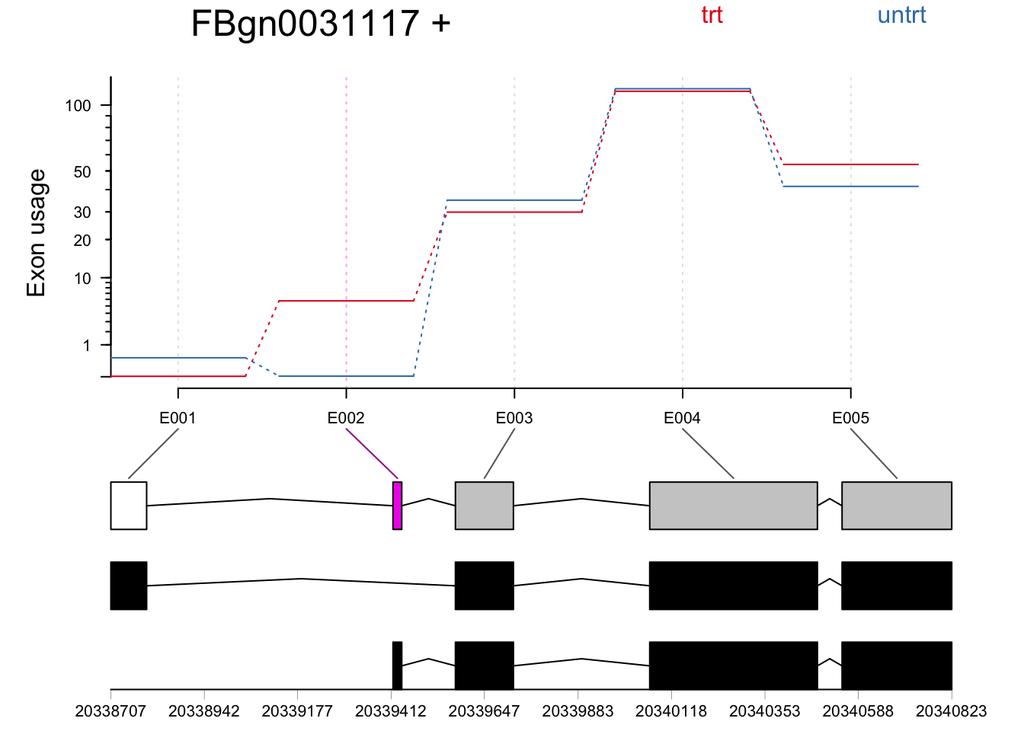

```r
# perform differential exon analysis (define data (counts + design))
dxd <- DEXSeqDataSetFromHTSeq(
           countfiles=file.path( sdir, samplesX$countfile ),
           sampleData = samplesX,
           design = ~ sample + exon + type:exon + cond:exon,
           flattenedfile=anno)

#normalize according to individual library size
dxd <- estimateSizeFactors( dxd )
#estimate data variability
dxd <- estimateDispersions( dxd )
#test for differential exon usage (p-value < 0.05 = rejection of Null hypothesis and indication of condition specific differential spicing)
dxd <- testForDEU( dxd )

#estimate exon FC between treated and non-treated samples
dxd = estimateExonFoldChanges( dxd, fitExpToVar="cond")
#generate results table of analysis
dxr <- DEXSeqResults( dxd)

#identify one of the genes which are differential spliced among the different conditions
diff_splic <- dxr$padj <0.05

dxr$diff <- diff_splic

#reduce data set to differential spliced exons
splice_data <-dxr[which(dxr$diff == TRUE),]

#identify top differential spliced gene
splice_data <- splice_data [order(splice_data$log2fold_untrt_trt, decreasing = F),]

#plot top differential spliced gene according to treatment
plotDEXSeq(dxr, "FBgn0031117", fitExpToVar = "cond", splicing = TRUE, legend = TRUE, expression = FALSE, displayTranscripts = TRUE)
```

The plot represents the expression estimates per exon individually per treatment (treated = red, untreated = blue). Shown in red is the exon (E002) that showed significant differential exon usage. Treatment lead to a significant higher expression of FBgn003117:E0002. Followed by this, not all exons are affected by the treatment.